# sst_post_error_slowing

Steps:

- load file
- number each trial consecutively based on the onset time
- number the following trial for each trial
- merge the file with itself, merging each trial with its following trial
- for each measure the post-trial time for a correct result

This paper probably has a good method, ‘How to measure post-error slowing: A confound and a simple solution’,

Look at their “simple solution”, and follow the method there. https://www.sciencedirect.com/science/article/abs/pii/S0022249612000454 https://www.sciencedirect.com/science/article/pii/S0022249612000454

https://www.frontiersin.org/articles/10.3389/fpsyg.2014.00119/full

For the variables, see https://www.dropbox.com/scl/fi/acc3pmvb28b9swz0cnr82/Info-about-Stop-Signal-Task-Baseline-Analysis.docx?dl=0&rlkey=18mfzinj70pmuhdv8d00nh84e found in /Berkman Lab/Devaluation/Papers/Frontiers - Health Special Issue we should use: PostErrorSlowW1_mean PostErrorSlowW1_median not sst_pes_limited

## load file

```r
library(tidyverse)
library(ggplot2)
Sys.setenv(R_CONFIG_ACTIVE = Sys.info()["nodename"])
dropbox_file_dir = config::get("dev_analysis_data_dir")
```

```r
Sys.setenv(R_CONFIG_ACTIVE = Sys.info()["nodename"])
dropbox_file_dir = config::get("dev_analysis_data_dir")
sst_all_data_filepath <- "~/Dropbox (University of Oregon)/UO-SAN Lab/Berkman Lab/Devaluation/analysis_files/data/sst_behavioral_data_all.csv"

sst_all_data_raw <- readr::read_csv(sst_all_data_filepath)
raw_survey_data <- readr::read_csv(paste0(dropbox_file_dir,"raw_survey_data.csv"))
```

```r
library(dplyr)
```

## About the Stop Signal Task

Task format The participant must respond to an arrow stimulus, by selecting one of two options, depending on the direction in which the arrow points. If an audio tone is present, the subject must withhold making that response (inhibition). The test consists of two parts: In the first part, the participant is introduced to the test and told to select the left-hand button when they see a left-pointing arrow and the right-hand button when they see a right-pointing arrow. There is one block of 16 trials for the participant to practice this. In the second part, the participant is told to continue selecting the buttons when they see the arrows but, if they hear an auditory signal (a beep), they should withhold their response and not select the button. Go task (e.g. press left when an arrow pointing to the left appears, and right when an arrow pointing to the right appears) Stop signal (e.g. a cross replacing the arrow OR a tone?) appears after a variable stop-signal delay (SSD), instructing participants to suppress the imminent go response.  
Conceptualizes the ability to inhibit the response as a race between a Go- and a Stop process that are triggered by the presentation of the Go and Stop-signal, respectively. If the Go process finishes first, the response will be executed. If the Stop process finishes first, the response will be inhibited (Teichert, 2015). Condition Type 1 CorrectGo (i.e. pressed left when an arrow pointing to the left appears, and right when an arrow pointing to the right appears) 2 FailedGo (i.e. did NOT press left when an arrow pointing to the left appears, and right when an arrow pointing to the right appears) 3 CorrectStop (i.e. Suppressed the go response) 4 FailedStop: (i.e. Failed to suppressed the go response)

### Calculate with respect to the pre-stop trial so that we can measure slowing/speeding in CS

We can be agnostic about it. simply record, for every trial where there is a reaction time before and after the trial, regardless of the trial type, what was the change?

First, we need to clean RTs

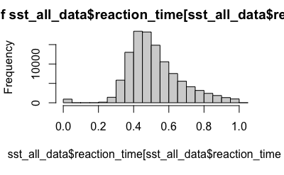

```r
sst_all_data<-sst_all_data_raw
sst_all_data$reaction_time_clean<-sst_all_data$reaction_time
sst_all_data$reaction_time_clean[sst_all_data$reaction_time==0]<-NA

hist(sst_all_data$reaction_time[sst_all_data$reaction_time>0.0])
```

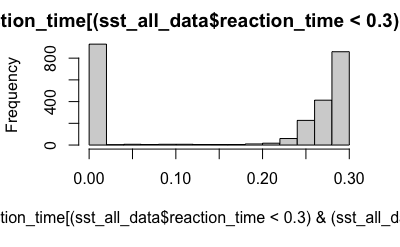

```r
hist(sst_all_data$reaction_time[(sst_all_data$reaction_time<0.3) & (sst_all_data$reaction_time>0.0)])
```

Based on eyeballing this histogram, reaction times start to increase around 0.2. So let’s make the cut-off at 0.15. Less than that, and they aren’t really a reaction.

```r
sst_all_data$reaction_time_clean[sst_all_data$reaction_time_clean<0.15]<-NA
```

```r
sst_all_data<-
  sst_all_data %>%
  mutate(has_response=!is.na(reaction_time_clean)) %>%
  mutate(follows_response_trial=lag(has_response,2),
         precedes_response_trial=lead(has_response,2)
         ) %>%
  mutate(post_pre_rt_change=lead(reaction_time_clean,2)-lag(reaction_time_clean,2))

#right. now we can view distributions of post_pre_rt_change by condition
ggplot(sst_all_data %>% filter(condition!="Cue"),
       aes(x=post_pre_rt_change,fill=condition))+
  geom_histogram()+facet_wrap(~condition,scales = "free")+
  geom_vline(xintercept=0)
```

[output not shown]

```r
for(cond in unique(sst_all_data$condition)){
  if(cond=="Cue"){next}
  print(cond)
  print("post minus pre trial reaction time change")
  sst_all_data_condition<-sst_all_data %>% filter(condition==cond)
  print(t.test(sst_all_data_condition$post_pre_rt_change))
}
```

```
[1] "CorrectGo"
[1] "post minus pre trial reaction time change"

    One Sample t-test

data:  sst_all_data_condition$post_pre_rt_change
t = -25.035, df = 72203, p-value < 2.2e-16
alternative hypothesis: true mean is not equal to 0
95 percent confidence interval:
 -0.01418708 -0.01212698
sample estimates:
  mean of x
-0.01315703

[1] "FailedStop"
[1] "post minus pre trial reaction time change"

    One Sample t-test

data:  sst_all_data_condition$post_pre_rt_change
t = 26.966, df = 11107, p-value < 2.2e-16
alternative hypothesis: true mean is not equal to 0
95 percent confidence interval:
 0.03697496 0.04277171
sample estimates:
 mean of x
0.03987334

[1] "CorrectStop"
[1] "post minus pre trial reaction time change"

    One Sample t-test

data:  sst_all_data_condition$post_pre_rt_change
t = 11.539, df = 9330, p-value < 2.2e-16
alternative hypothesis: true mean is not equal to 0
95 percent confidence interval:
 0.01515258 0.02135403
sample estimates:
mean of x
0.0182533

[1] "FailedGo"
[1] "post minus pre trial reaction time change"

    One Sample t-test

data:  sst_all_data_condition$post_pre_rt_change
t = -13.21, df = 1547, p-value < 2.2e-16
alternative hypothesis: true mean is not equal to 0
95 percent confidence interval:
 -0.07171381 -0.05317069
sample estimates:
  mean of x
-0.06244225
```

```r
#what about only if it's a trial preceded and followed by a CG trial?
```

# individual differences….

Let’s create individual subject level values and see if these correlate with individaul difference measures

So, individual difference measures will be: - post-pre-rt change for each of the four trial types - differnce in CS-FS change

| subid | condition | pmprtd_mean | pmprtd_sd | pmprtd_n |
| --- | --- | --- | --- | --- |
| DEV004 | Go | -1.068079e-02 | 0.13075219 | 376 |
| DEV004 | Stop | -3.929931e-03 | 0.13769808 | 98 |
| DEV005 | Go | -2.146150e-02 | 0.11862858 | 228 |
| DEV005 | Stop | 4.910378e-02 | 0.16639040 | 70 |
| DEV006 | Go | -3.171140e-03 | 0.15664375 | 71 |
| DEV006 | Stop | 2.704382e-02 | 0.12228364 | 17 |
| DEV007 | Go | -2.011858e-02 | 0.14031107 | 74 |
| DEV007 | Stop | 2.325182e-02 | 0.14769630 | 21 |
| DEV008 | Go | -8.255574e-03 | 0.12337995 | 162 |
| DEV008 | Stop | 3.349510e-02 | 0.14724107 | 50 |

[output cut: 560 more lines]

```r
raw_survey_cols <-c("SID","BFI_10","BFI_11","BFI_34")
raw_survey_data_to_merge<-raw_survey_data[raw_survey_data$item %in% raw_survey_cols,] %>%
  pivot_wider(id_cols="SID",names_from="item",values_from="value")
```

```r
data_by_ppt_raw <- read_csv(paste0(dropbox_file_dir,"data_by_ppt.csv"))
data_by_ppt_all <- data_by_ppt_raw %>%
  merge(sst_subj_means,by.x="SID",by.y="subid") %>%
  merge(raw_survey_data_to_merge,by="SID")
```

```r
t.test(data_by_ppt_all$pmprtd_mean_CorrectGo)
```

```
    One Sample t-test

data:  data_by_ppt_all$pmprtd_mean_CorrectGo
t = -17.733, df = 252, p-value < 2.2e-16
alternative hypothesis: true mean is not equal to 0
95 percent confidence interval:
 -0.01395837 -0.01116786
sample estimates:
  mean of x
-0.01256312
```

```r
t.test(data_by_ppt_all$pmprtd_mean_CorrectStop)
```

```
    One Sample t-test

data:  data_by_ppt_all$pmprtd_mean_CorrectStop
t = 7.2619, df = 249, p-value = 4.871e-12
alternative hypothesis: true mean is not equal to 0
95 percent confidence interval:
 0.01389128 0.02423041
sample estimates:
 mean of x
0.01906084
```

```r
t.test(data_by_ppt_all$pmprtd_mean_FailedStop)
```

```
    One Sample t-test

data:  data_by_ppt_all$pmprtd_mean_FailedStop
t = 19.985, df = 252, p-value < 2.2e-16
alternative hypothesis: true mean is not equal to 0
95 percent confidence interval:
 0.04068669 0.04958245
sample estimates:
 mean of x
0.04513457
```

```r
t.test(data_by_ppt_all$pmprtd_mean_FailedStop-data_by_ppt_all$pmprtd_mean_CorrectStop)
```

```
    One Sample t-test

data:  data_by_ppt_all$pmprtd_mean_FailedStop - data_by_ppt_all$pmprtd_mean_CorrectStop
t = 7.6428, df = 249, p-value = 4.597e-13
alternative hypothesis: true mean is not equal to 0
95 percent confidence interval:
 0.0196619 0.0333136
sample estimates:
 mean of x
0.02648775
```

```r
data_by_ppt_all$pmprtd_meanPostStopSlowing<-data_by_ppt_all$pmprtd_mean_CorrectStop+data_by_ppt_all$pmprtd_mean_FailedStop
data_by_ppt_all$pmprtd_sdPostStopSlowing<-rowMeans(data_by_ppt_all[,c("pmprtd_sd_CorrectStop","pmprtd_sd_FailedStop")])
data_by_ppt_all$pmprtd_meanFailureRelatedSlowing<-data_by_ppt_all$pmprtd_mean_FailedStop-data_by_ppt_all$pmprtd_mean_CorrectStop
data_by_ppt_all$BFI_positivity<-as.numeric(data_by_ppt_all$BFI_10)+as.numeric(data_by_ppt_all$BFI_11)
```

```r
cor.test(
  data_by_ppt_all$pmprtd_meanFailureRelatedSlowing,
  data_by_ppt_all$BIS_11)
```

```
    Pearson's product-moment correlation

data:  data_by_ppt_all$pmprtd_meanFailureRelatedSlowing and data_by_ppt_all$BIS_11
t = -0.84897, df = 248, p-value = 0.3967
alternative hypothesis: true correlation is not equal to 0
95 percent confidence interval:
 -0.1767181  0.0707079
sample estimates:
        cor
-0.05383135
```

```r
cor.test(data_by_ppt_all$BFI_extraversion,data_by_ppt_all$pmprtd_mean_CorrectGo)
```

```
    Pearson's product-moment correlation

data:  data_by_ppt_all$BFI_extraversion and data_by_ppt_all$pmprtd_mean_CorrectGo
t = 0.31219, df = 251, p-value = 0.7552
alternative hypothesis: true correlation is not equal to 0
95 percent confidence interval:
 -0.1038789  0.1426828
sample estimates:
       cor
0.01970146
```

```r
cor.test(data_by_ppt_all$BFI_extraversion,data_by_ppt_all$pmprtd_mean_CorrectStop)
```

```
    Pearson's product-moment correlation

data:  data_by_ppt_all$BFI_extraversion and data_by_ppt_all$pmprtd_mean_CorrectStop
t = 1.4266, df = 248, p-value = 0.155
alternative hypothesis: true correlation is not equal to 0
95 percent confidence interval:
 -0.03423224  0.21191298
sample estimates:
       cor
0.09021793
```

```r
cor.test(data_by_ppt_all$BFI_extraversion,data_by_ppt_all$pmprtd_meanFailureRelatedSlowing)
```

```
    Pearson's product-moment correlation

data:  data_by_ppt_all$BFI_extraversion and data_by_ppt_all$pmprtd_meanFailureRelatedSlowing
t = -0.74309, df = 248, p-value = 0.4581
alternative hypothesis: true correlation is not equal to 0
95 percent confidence interval:
 -0.17020531  0.07738592
sample estimates:
        cor
-0.04713362
```

```r
cor.test(data_by_ppt_all$BIS_11,data_by_ppt_all$pmprtd_mean_CorrectStop)
```

```
    Pearson's product-moment correlation

data:  data_by_ppt_all$BIS_11 and data_by_ppt_all$pmprtd_mean_CorrectStop
t = 0.89354, df = 248, p-value = 0.3724
alternative hypothesis: true correlation is not equal to 0
95 percent confidence interval:
 -0.06789545  0.17945449
sample estimates:
       cor
0.05664874
```

```r
cor.test(data_by_ppt_all$pmprtd_meanFailureRelatedSlowing,data_by_ppt_all$BIS_11)
```

```
    Pearson's product-moment correlation

data:  data_by_ppt_all$pmprtd_meanFailureRelatedSlowing and data_by_ppt_all$BIS_11
t = -0.84897, df = 248, p-value = 0.3967
alternative hypothesis: true correlation is not equal to 0
95 percent confidence interval:
 -0.1767181  0.0707079
sample estimates:
        cor
-0.05383135
```

```r
cor.test(data_by_ppt_all$pmprtd_mean_CorrectGo,
         as.numeric(data_by_ppt_all$BFI_11)
         )
```

```
    Pearson's product-moment correlation

data:  data_by_ppt_all$pmprtd_mean_CorrectGo and as.numeric(data_by_ppt_all$BFI_11)
t = 0.037793, df = 251, p-value = 0.9699
alternative hypothesis: true correlation is not equal to 0
95 percent confidence interval:
 -0.1209781  0.1256765
sample estimates:
        cor
0.002385462
```

```r
cor.test(data_by_ppt_all$pmprtd_mean_CorrectStop,
         as.numeric(data_by_ppt_all$BFI_34)
         )
```

```
    Pearson's product-moment correlation

data:  data_by_ppt_all$pmprtd_mean_CorrectStop and as.numeric(data_by_ppt_all$BFI_34)
t = 1.0537, df = 248, p-value = 0.2931
alternative hypothesis: true correlation is not equal to 0
95 percent confidence interval:
 -0.05778587  0.18925919
sample estimates:
       cor
0.06675976
```

```r
cor.test(data_by_ppt_all$pmprtd_mean_CorrectStop-data_by_ppt_all$pmprtd_mean_CorrectGo,
         as.numeric(data_by_ppt_all$BFI_34)
         )
```

```
    Pearson's product-moment correlation

data:  data_by_ppt_all$pmprtd_mean_CorrectStop - data_by_ppt_all$pmprtd_mean_CorrectGo and as.numeric(data_by_ppt_all$BFI_34)
t = 0.92519, df = 248, p-value = 0.3558
alternative hypothesis: true correlation is not equal to 0
95 percent confidence interval:
 -0.06589792  0.18139568
sample estimates:
       cor
0.05864858
```

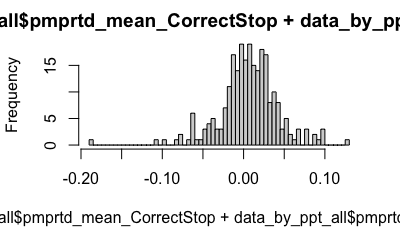

```r
hist(data_by_ppt_all$pmprtd_mean_CorrectStop+data_by_ppt_all$pmprtd_mean_CorrectGo,breaks=100)
```

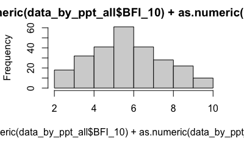

```r
hist(as.numeric(data_by_ppt_all$BFI_10)+as.numeric(data_by_ppt_all$BFI_11))
```

```r
cor.test(data_by_ppt_all$pmprtd_mean_CorrectStop,
         data_by_ppt_all$BFI_positivity+as.numeric(data_by_ppt_all$BFI_34)
         )
```

```
    Pearson's product-moment correlation

data:  data_by_ppt_all$pmprtd_mean_CorrectStop and data_by_ppt_all$BFI_positivity + as.numeric(data_by_ppt_all$BFI_34)
t = 1.835, df = 248, p-value = 0.0677
alternative hypothesis: true correlation is not equal to 0
95 percent confidence interval:
 -0.008445668  0.236414743
sample estimates:
      cor
0.1157426
```

```r
cor.test(data_by_ppt_all$pmprtd_mean_CorrectStop+data_by_ppt_all$pmprtd_mean_FailedStop,
         data_by_ppt_all$BFI_positivity+as.numeric(data_by_ppt_all$BFI_34)
         )
```

```
    Pearson's product-moment correlation

data:  data_by_ppt_all$pmprtd_mean_CorrectStop + data_by_ppt_all$pmprtd_mean_FailedStop and data_by_ppt_all$BFI_positivity + as.numeric(data_by_ppt_all$BFI_34)
t = 2.1876, df = 248, p-value = 0.02963
alternative hypothesis: true correlation is not equal to 0
95 percent confidence interval:
 0.01376064 0.25726800
sample estimates:
      cor
0.1375927
```

```r
cor.test(data_by_ppt_all$pmprtd_meanPostStopSlowing,
         as.numeric(data_by_ppt_all$BFI_10)+as.numeric(data_by_ppt_all$BFI_11)
         )
```

```
    Pearson's product-moment correlation

data:  data_by_ppt_all$pmprtd_meanPostStopSlowing and as.numeric(data_by_ppt_all$BFI_10) + as.numeric(data_by_ppt_all$BFI_11)
t = 2.399, df = 248, p-value = 0.01718
alternative hypothesis: true correlation is not equal to 0
95 percent confidence interval:
 0.02703559 0.26962671
sample estimates:
      cor
0.1505975
```

```r
cor.test(data_by_ppt_all$pmprtd_meanPostStopSlowing,
         data_by_ppt_all$BFI_extraversion
         )
```

```
    Pearson's product-moment correlation

data:  data_by_ppt_all$pmprtd_meanPostStopSlowing and data_by_ppt_all$BFI_extraversion
t = 1.4133, df = 248, p-value = 0.1588
alternative hypothesis: true correlation is not equal to 0
95 percent confidence interval:
 -0.03506811  0.21111354
sample estimates:
      cor
0.0893878
```

```r
cor.test(data_by_ppt_all$pmprtd_meanPostStopSlowing,
         as.numeric(data_by_ppt_all$BFI_11)
         )
```

```
    Pearson's product-moment correlation

data:  data_by_ppt_all$pmprtd_meanPostStopSlowing and as.numeric(data_by_ppt_all$BFI_11)
t = 2.3166, df = 248, p-value = 0.02134
alternative hypothesis: true correlation is not equal to 0
95 percent confidence interval:
 0.02186528 0.26482274
sample estimates:
      cor
0.1455375
```

```r
cor.test(data_by_ppt_all$pmprtd_meanPostStopSlowing,
         as.numeric(data_by_ppt_all$RTFS_factor_1)
         )
```

```
    Pearson's product-moment correlation

data:  data_by_ppt_all$pmprtd_meanPostStopSlowing and as.numeric(data_by_ppt_all$RTFS_factor_1)
t = -0.040652, df = 193, p-value = 0.9676
alternative hypothesis: true correlation is not equal to 0
95 percent confidence interval:
 -0.1433796  0.1376427
sample estimates:
        cor
-0.00292621
```

```r
cor.test(data_by_ppt_all$pmprtd_meanPostStopSlowing,
         as.numeric(data_by_ppt_all$RTFS_factor_2)
         )
```

```
    Pearson's product-moment correlation

data:  data_by_ppt_all$pmprtd_meanPostStopSlowing and as.numeric(data_by_ppt_all$RTFS_factor_2)
t = -0.47918, df = 198, p-value = 0.6323
alternative hypothesis: true correlation is not equal to 0
95 percent confidence interval:
 -0.1719629  0.1052039
sample estimates:
        cor
-0.03403388
```

```r
cor.test(data_by_ppt_all$pmprtd_meanFailureRelatedSlowing,
         as.numeric(data_by_ppt_all$RTFS_factor_2)
         )
```

```
    Pearson's product-moment correlation

data:  data_by_ppt_all$pmprtd_meanFailureRelatedSlowing and as.numeric(data_by_ppt_all$RTFS_factor_2)
t = 1.5312, df = 198, p-value = 0.1273
alternative hypothesis: true correlation is not equal to 0
95 percent confidence interval:
 -0.0310266  0.2432699
sample estimates:
      cor
0.1081801
```

```r
cor.test(data_by_ppt_all$pmprtd_meanFailureRelatedSlowing,
         as.numeric(data_by_ppt_all$RTFS_factor_1)
         )
```

```
    Pearson's product-moment correlation

data:  data_by_ppt_all$pmprtd_meanFailureRelatedSlowing and as.numeric(data_by_ppt_all$RTFS_factor_1)
t = 0.56108, df = 193, p-value = 0.5754
alternative hypothesis: true correlation is not equal to 0
95 percent confidence interval:
 -0.1007289  0.1798472
sample estimates:
       cor
0.04035459
```

```r
cor.test(data_by_ppt_all$pmprtd_meanPostStopSlowing,
         as.numeric(data_by_ppt_all$BFI_10)+as.numeric(data_by_ppt_all$BFI_11))
```

```
    Pearson's product-moment correlation

data:  data_by_ppt_all$pmprtd_meanPostStopSlowing and as.numeric(data_by_ppt_all$BFI_10) + as.numeric(data_by_ppt_all$BFI_11)
t = 2.399, df = 248, p-value = 0.01718
alternative hypothesis: true correlation is not equal to 0
95 percent confidence interval:
 0.02703559 0.26962671
sample estimates:
      cor
0.1505975
```

```r
cor.test(data_by_ppt_all$pmprtd_meanPostStopSlowing,
         as.numeric(data_by_ppt_all$BFI_10)+as.numeric(data_by_ppt_all$BFI_11),method = "spearman")
```

```
Cannot compute exact p-value with ties
```

```
    Spearman's rank correlation rho

data:  data_by_ppt_all$pmprtd_meanPostStopSlowing and as.numeric(data_by_ppt_all$BFI_10) + as.numeric(data_by_ppt_all$BFI_11)
S = 2226007, p-value = 0.02165
alternative hypothesis: true rho is not equal to 0
sample estimates:
      rho
0.1451996
```

```r
cor.test(data_by_ppt_all$pmprtd_meanPostStopSlowing,
         data_by_ppt_all$BFI_positivity)
```

```
    Pearson's product-moment correlation

data:  data_by_ppt_all$pmprtd_meanPostStopSlowing and data_by_ppt_all$BFI_positivity
t = 2.399, df = 248, p-value = 0.01718
alternative hypothesis: true correlation is not equal to 0
95 percent confidence interval:
 0.02703559 0.26962671
sample estimates:
      cor
0.1505975
```

```r
cor.test(data_by_ppt_all$pmprtd_mean_Stop,
         data_by_ppt_all$BFI_positivity)
```

```
    Pearson's product-moment correlation

data:  data_by_ppt_all$pmprtd_mean_Stop and data_by_ppt_all$BFI_positivity
t = 1.7662, df = 251, p-value = 0.07857
alternative hypothesis: true correlation is not equal to 0
95 percent confidence interval:
 -0.01270369  0.23096976
sample estimates:
      cor
0.1107979
```

```r
cor.test(data_by_ppt_all$SST_PostErrorSlowW1_median,
         data_by_ppt_all$BFI_positivity)
```

```
    Pearson's product-moment correlation

data:  data_by_ppt_all$SST_PostErrorSlowW1_median and data_by_ppt_all$BFI_positivity
t = -0.25192, df = 227, p-value = 0.8013
alternative hypothesis: true correlation is not equal to 0
95 percent confidence interval:
 -0.1460427  0.1131684
sample estimates:
        cor
-0.01671805
```

[figure not shown]

```r
cor.test(data_by_ppt_all$pmprtd_mean_CorrectStop-data_by_ppt_all$pmprtd_mean_CorrectGo,
         as.numeric(data_by_ppt_all$BFI_11)
         )
```

```
    Pearson's product-moment correlation

data:  data_by_ppt_all$pmprtd_mean_CorrectStop - data_by_ppt_all$pmprtd_mean_CorrectGo and as.numeric(data_by_ppt_all$BFI_11)
t = 1.4941, df = 248, p-value = 0.1364
alternative hypothesis: true correlation is not equal to 0
95 percent confidence interval:
 -0.02996938  0.21598491
sample estimates:
       cor
0.09444881
```

```r
cor.test(data_by_ppt_all$pmprtd_mean_CorrectStop-data_by_ppt_all$pmprtd_mean_FailedStop,
         as.numeric(data_by_ppt_all$BFI_11)
         )
```

```
    Pearson's product-moment correlation

data:  data_by_ppt_all$pmprtd_mean_CorrectStop - data_by_ppt_all$pmprtd_mean_FailedStop and as.numeric(data_by_ppt_all$BFI_11)
t = 0.29475, df = 248, p-value = 0.7684
alternative hypothesis: true correlation is not equal to 0
95 percent confidence interval:
 -0.1055988  0.1424497
sample estimates:
       cor
0.01871338
```